# Housing Prices Prediction

For this project I am interested in predicting housing prices based on typical features like number rooms, distance to the ocean, and location. This data set is from houses in California and was retrieved from Kaggle.

First thing is to load in the data as well as the packages I will be using.

```r
rm(list = ls())

setwd("C:/Users/cayde/OneDrive/Data Science/R Projects/Housing Prices")

data <- read.csv("housing.csv")

library(dplyr)
library(ggplot2)

library(reshape2) #cormelt
library(Hmisc) #Hist.data.frame
library(car) #VIF
library(randomForest)
```

Next I want to inspect the data. One of the most important aspects is how clean or complete the data set is.

```r
sapply(data, function(x){sum(is.na(x))}) # checking for NA's
```

```
         longitude           latitude housing_median_age        total_rooms     total_bedrooms         population         households      median_income median_house_value    ocean_proximity
                 0                  0                  0                  0                207                  0                  0                  0                  0                  0
```

```r
missing_data <- data[is.na(data$total_bedrooms),]
```

Fortunately this data looks quite clean, only one column is missing info and less than 1% of observations are missing.

Although highly unlikely I want to see if the missing data differs systematically from the complete data. Is there any reason why certain houses may have missing data in the data set?

Since most of the data is continuous, I use a t.test to compare the means between the observations with full data and those with missing data.

```r
numeric_vars <- names(data[sapply(data, is.numeric)]) #getting a list of the numeric variables
numeric_vars <- numeric_vars[!numeric_vars %in% "total_bedrooms"] # excluding the variable with missing data

# running a t-test for every variable
for(variable in numeric_vars){
  test <- t.test(data[,variable], missing_data[,variable])
  print(test)
}
```

```
    Welch Two Sample t-test

data:  data[, variable] and missing_data[, variable]
t = -0.69485, df = 210.16, p-value = 0.4879
alternative hypothesis: true difference in means is not equal to 0
95 percent confidence interval:
 -0.3727456  0.1784575
sample estimates:
mean of x mean of y
-119.5697 -119.4726


    Welch Two Sample t-test

data:  data[, variable] and missing_data[, variable]
t = 0.91606, df = 210.31, p-value = 0.3607
alternative hypothesis: true difference in means is not equal to 0
95 percent confidence interval:
 -0.1546242  0.4230814
sample estimates:
mean of x mean of y
 35.63186  35.49763


    Welch Two Sample t-test

data:  data[, variable] and missing_data[, variable]
t = -0.75464, df = 210.6, p-value = 0.4513
alternative hypothesis: true difference in means is not equal to 0
95 percent confidence interval:
 -2.279481  1.017392
sample estimates:
mean of x mean of y
 28.63949  29.27053


    Welch Two Sample t-test

data:  data[, variable] and missing_data[, variable]
t = 0.58458, df = 212.2, p-value = 0.5595
```

[output cut: 39 more lines]

```
sample estimates:
mean of x mean of y
 3.870671  3.822244


    Welch Two Sample t-test

data:  data[, variable] and missing_data[, variable]
t = 0.10877, df = 210.44, p-value = 0.9135
alternative hypothesis: true difference in means is not equal to 0
95 percent confidence interval:
 -14529.30  16226.37
sample estimates:
mean of x mean of y
 206855.8  206007.3
```

None of the p values reach statistical significance. This indicates that there are likely no systematic differences for the observations that are missing bedroom data. I thus feel more confident about removing these observations. I do this to create a perfectly clean data set as NA’s can be very annoying.

```r
data <- na.omit(data)
```

Taking a look at the data everything seems in order. The max median income and house value suggest that their may be an artificial cap in the data.

```r
for(variable in numeric_vars){
  print(variable)
  print(summary(data[,variable]))
}
```

```
[1] "longitude"
   Min. 1st Qu.  Median    Mean 3rd Qu.    Max.
 -124.3  -121.8  -118.5  -119.6  -118.0  -114.3
[1] "latitude"
   Min. 1st Qu.  Median    Mean 3rd Qu.    Max.
  32.54   33.93   34.26   35.63   37.72   41.95
[1] "housing_median_age"
   Min. 1st Qu.  Median    Mean 3rd Qu.    Max.
   1.00   18.00   29.00   28.63   37.00   52.00
[1] "total_rooms"
   Min. 1st Qu.  Median    Mean 3rd Qu.    Max.
      2    1450    2127    2636    3143   39320
[1] "population"
   Min. 1st Qu.  Median    Mean 3rd Qu.    Max.
      3     787    1166    1425    1722   35682
[1] "households"
   Min. 1st Qu.  Median    Mean 3rd Qu.    Max.
    1.0   280.0   409.0   499.4   604.0  6082.0
[1] "median_income"
   Min. 1st Qu.  Median    Mean 3rd Qu.    Max.
 0.4999  2.5637  3.5365  3.8712  4.7440 15.0001
[1] "median_house_value"
   Min. 1st Qu.  Median    Mean 3rd Qu.    Max.
  14999  119500  179700  206864  264700  500001
```

```r
rm(numeric_vars)
```

The first method I would like to use is linear regression. Although there are more complicated and fancier models I am a big fan of Ockam’s Razor, which states that causes should not be multiplied beyond their necessity, or in laymen’s terms, don’t make things more complicated then they need to be.

A Linear Regression, however, makes certain assumptions about the data. One of those assumptions is that the data is normally distributed. Using Histograms I can have a visual check to see if this is true.

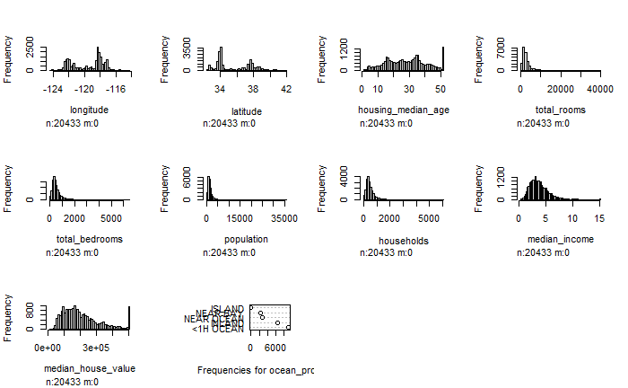

```r
hist.data.frame(data)
```

Some of the data do not look normally distributed Let’s take a closer look.

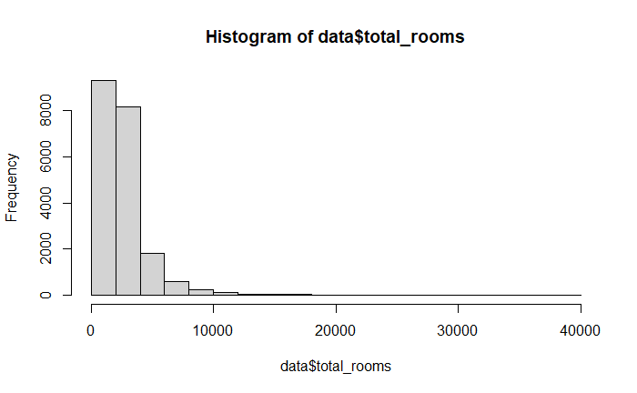

```r
# hist.data.frame(select(data, c("total_rooms", "total_bedrooms", "population", "households")))
hist(data$total_rooms)
```

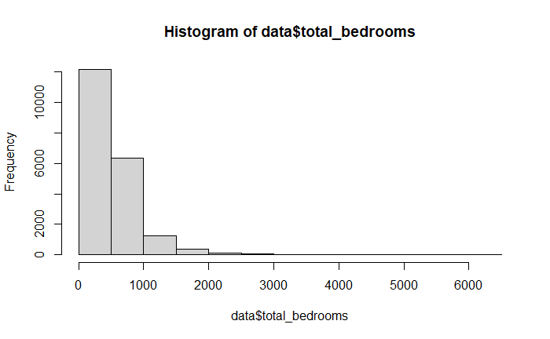

```r
hist(data$total_bedrooms)
```

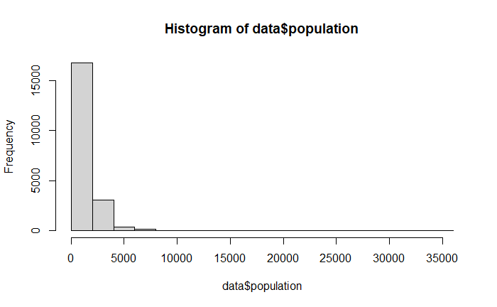

```r
hist(data$population)
```

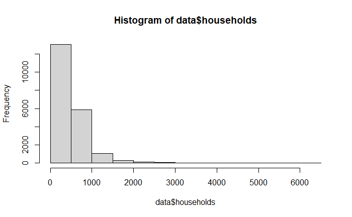

```r
hist(data$households)
```

These variables appear to be exponentially distributed Let’s log transform them to see if we get a distribution that looks more normal.

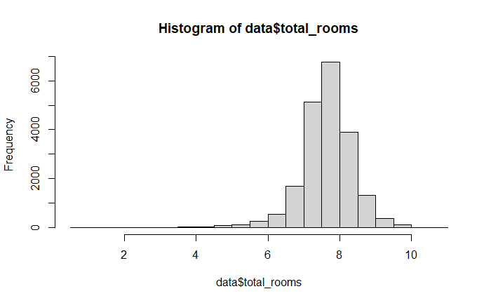

```r
data$total_rooms <- log(data$total_rooms)
data$total_bedrooms <- log(data$total_bedrooms)
data$population <- log(data$population)
data$households <- log(data$households)

#hist.data.frame(select(data, c("total_rooms", "total_bedrooms", "population", "households")))
hist(data$total_rooms)
```

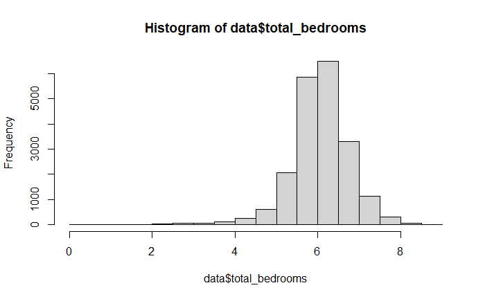

```r
hist(data$total_bedrooms)
```

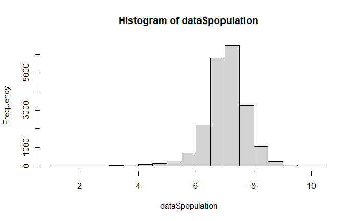

```r
hist(data$population)
```

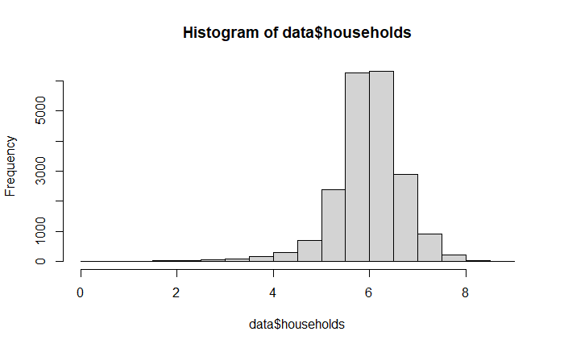

```r
hist(data$households)
```

These look much better! Let’s make a couple of other minor adjustments to the data.

```r
# There are only 5 houses on islands, so that variable is dropped
table(data$ocean_proximity)
```

```
 <1H OCEAN     INLAND     ISLAND   NEAR BAY NEAR OCEAN
      9034       6496          5       2270       2628
```

```r
data <- data[data$ocean_proximity != "ISLAND",]

# Converting the geographic variable into a factor
class(data$ocean_proximity)
```

```
[1] "character"
```

```r
data$ocean_proximity <- as.factor(data$ocean_proximity)
```

Now that the data is cleaned and transformed we can split the data into training and testing sets. Splitting the data this way ensures we do not ‘overfit’ the model or chase any noise. By keeping a section of the data reserved, we can better ensure that the improvements in accuracy are not due to the model being overtrained.

```r
set.seed(38483)

assignment <- sample(c("train", "test"), nrow(data), replace = TRUE, prob = c(.8, .2))

train <- data[assignment == "train",]
test <- data[assignment == "test",]

rm(assignment)
```

Now that we have two sets, let’s estimate a linear model on the training set.

```r
lin_mod_full <- lm(median_house_value ~ ., train)
summary(lin_mod_full)
```

```
Call:
lm(formula = median_house_value ~ ., data = train)

Residuals:
    Min      1Q  Median      3Q     Max
-600019  -39990   -8902   28304  533181

Coefficients:
                            Estimate Std. Error t value Pr(>|t|)
(Intercept)               -2339425.9    97210.6  -24.07   <2e-16 ***
longitude                   -29402.3     1123.0  -26.18   <2e-16 ***
latitude                    -28579.5     1111.6  -25.71   <2e-16 ***
housing_median_age            1025.1       47.0   21.81   <2e-16 ***
total_rooms                 -51497.0     3364.9  -15.30   <2e-16 ***
total_bedrooms              100357.1     4340.6   23.12   <2e-16 ***
population                  -86783.6     1999.5  -43.40   <2e-16 ***
households                   43532.5     3991.4   10.91   <2e-16 ***
median_income                42744.3      443.5   96.38   <2e-16 ***
ocean_proximityINLAND       -32144.5     1905.2  -16.87   <2e-16 ***
ocean_proximityNEAR BAY      -6764.1     2087.4   -3.24   0.0012 **
ocean_proximityNEAR OCEAN     -564.8     1710.3   -0.33   0.7412
---
Signif. codes:  0 ‘***’ 0.001 ‘**’ 0.01 ‘*’ 0.05 ‘.’ 0.1 ‘ ’ 1

Residual standard error: 66630 on 16377 degrees of freedom
Multiple R-squared:  0.6674,    Adjusted R-squared:  0.6672
F-statistic:  2988 on 11 and 16377 DF,  p-value: < 2.2e-16
```

Running Linear models requires certain assumptions about the data. I have already dealt with the normality of the data, and I have no reason to believe the observations are not independent of each other. However, now that I have estimated the model I need to check for multicolinearity, homoskedasticity, and normality of errors.

Looking at the coefficients of the linear model, I can see that the total number of rooms is negatively correlated with the price, which seems backwards; how does having more rooms make a house cost less? There is also a variable named total number of bedrooms, which is not only positively correlated, but sounds very similar to total number of rooms. The variables ‘total_rooms’ and ’total_bedrooms are likely highly correlated, thus causing strange behavior for the coefficients. Let’s run some tests and find out.

```r
cormat <- round(cor(data[,sapply(data, is.numeric)]), 2)
cormat
```

```
                   longitude latitude housing_median_age total_rooms total_bedrooms population households median_income median_house_value
longitude               1.00    -0.92              -0.11        0.03           0.06       0.11       0.06         -0.02              -0.05
latitude               -0.92     1.00               0.01       -0.03          -0.07      -0.14      -0.09         -0.08              -0.14
housing_median_age     -0.11     0.01               1.00       -0.31          -0.27      -0.24      -0.24         -0.12               0.11
total_rooms             0.03    -0.03              -0.31        1.00           0.95       0.86       0.93          0.21               0.16
total_bedrooms          0.06    -0.07              -0.27        0.95           1.00       0.90       0.97         -0.03               0.05
population              0.11    -0.14              -0.24        0.86           0.90       1.00       0.93          0.00              -0.02
households              0.06    -0.09              -0.24        0.93           0.97       0.93       1.00          0.00               0.07
median_income          -0.02    -0.08              -0.12        0.21          -0.03       0.00       0.00          1.00               0.69
median_house_value     -0.05    -0.14               0.11        0.16           0.05      -0.02       0.07          0.69               1.00
```

```r
vif(lin_mod_full)
```

```
                        GVIF Df GVIF^(1/(2*Df))
longitude          18.620065  1        4.315097
latitude           20.782394  1        4.558771
housing_median_age  1.289461  1        1.135544
total_rooms        23.297368  1        4.826735
total_bedrooms     36.867929  1        6.071897
population          7.982497  1        2.825331
households         31.289248  1        5.593679
median_income       2.616911  1        1.617687
ocean_proximity     4.207420  3        1.270582
```

The covariance matrix allows us to see how the covariates or features of our data are correlated with each other. Calculating a variation inflaction factor score (VIF) we see that total rooms and number of bedrooms are near 5 and 6. This is normally the cutoff point for collinearity.

```r
lin_mod_rooms<- lm(median_house_value ~ housing_median_age + total_rooms +
                     population + median_income + ocean_proximity, train)

summary(lin_mod_rooms)
```

```
Call:
lm(formula = median_house_value ~ housing_median_age + total_rooms +
    population + median_income + ocean_proximity, data = train)

Residuals:
    Min      1Q  Median      3Q     Max
-524312  -44668  -11111   29950  497894

Coefficients:
                           Estimate Std. Error t value Pr(>|t|)
(Intercept)                 1883.72    6827.98   0.276    0.783
housing_median_age          1126.46      49.84  22.604  < 2e-16 ***
total_rooms                53715.04    1679.62  31.981  < 2e-16 ***
population                -48691.59    1660.89 -29.317  < 2e-16 ***
median_income              33370.22     341.93  97.595  < 2e-16 ***
ocean_proximityINLAND     -82119.89    1413.67 -58.090  < 2e-16 ***
ocean_proximityNEAR BAY     3188.28    1953.10   1.632    0.103
ocean_proximityNEAR OCEAN  11134.59    1780.57   6.253 4.12e-10 ***
---
Signif. codes:  0 ‘***’ 0.001 ‘**’ 0.01 ‘*’ 0.05 ‘.’ 0.1 ‘ ’ 1

Residual standard error: 71290 on 16381 degrees of freedom
Multiple R-squared:  0.6192,    Adjusted R-squared:  0.619
F-statistic:  3805 on 7 and 16381 DF,  p-value: < 2.2e-16
```

```r
vif(lin_mod_rooms)
```

```
                       GVIF Df GVIF^(1/(2*Df))
housing_median_age 1.266178  1        1.125246
total_rooms        5.070152  1        2.251700
population         4.810795  1        2.193352
median_income      1.358804  1        1.165677
ocean_proximity    1.316898  3        1.046949
```

The new model has significantly less multicollineartiy If I was interested in the impact of the particular variables of the model I would likely go with the reduced model as the coefficients are more stable, however I am more interested in predictive power, and this new model has less predictive power.

Let’s check for the other assumptions of linear regression, namely normality of errors and homoskedasticity.

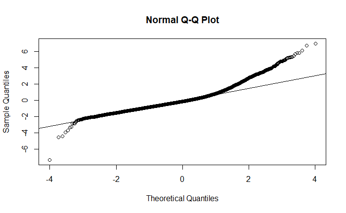

```r
# Normality of Errors
#####################

qqnorm(scale(lin_mod_rooms$residuals))
qqline(scale(lin_mod_rooms$residuals))
```

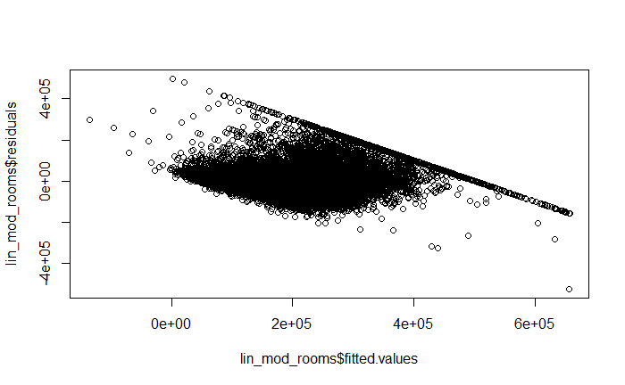

```r
#Homoskedasticity
plot(lin_mod_rooms$fitted.values, lin_mod_rooms$residuals)
```

Plotting the residuals and fitted values against each other we can see that there does appear to be a relationship between the variables, thus violating the assumption of Homoskedasticity. There is also a very strong diagonal line on the plot. Let’s check the data for peculiarities.

```r
sum(train$median_house_value == max(train$median_house_value))
```

```
[1] 777
```

There are 777 houses at maximum price “500001”, this suggests a ‘ceiling’ in our data and creates artificiality Let’s remove those values and retrain the model.

```r
train <- train[train$median_house_value != max(train$median_house_value),]

lin_mod_rooms<- lm(median_house_value ~ housing_median_age + total_rooms +
                     population + median_income + ocean_proximity, train)
```

Removing the values get’s rid of the strong diagonal line but the errors are still not normally distributed

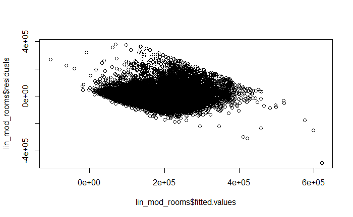

```r
plot(lin_mod_rooms$fitted.values, lin_mod_rooms$residuals)
```

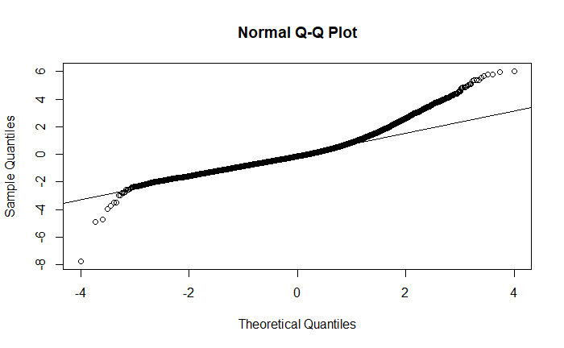

```r
qqnorm(scale(lin_mod_rooms$residuals))
qqline(scale(lin_mod_rooms$residuals))
```

Although there appears to be a negative correlation between the residuals this relationship is not statistically significant. Thus we may have homoskedasticity

```r
cor.test(lin_mod_rooms$fitted.values, lin_mod_rooms$residuals)
```

```
    Pearson's product-moment correlation

data:  lin_mod_rooms$fitted.values and lin_mod_rooms$residuals
t = 7.42e-15, df = 15610, p-value = 1
alternative hypothesis: true correlation is not equal to 0
95 percent confidence interval:
 -0.01568646  0.01568646
sample estimates:
         cor
5.938845e-17
```

Now that we’ve trained a model let’s apply it to our test data.

```r
pred_test <- predict(lin_mod_rooms, test)

rss <- sum((test$median_house_value - pred_test)^2)
tss <- sum((test$median_house_value - mean(test$median_house_value))^2)

r_squared <- 1 - (rss/tss)
r_squared
```

```
[1] 0.62256
```

Random forest models make less assumptions about the structure of the data While there is a risk of overfitting, we over already split the data into training and testing sets, so if we are overfitting we will know. Random forests are not as easy to interpret as a linear regression models, in which the coefficients are a straight-forward linear interpretation However, if the goal is prediction, the Random Forest Model is often quite good

```r
rf_model <- randomForest(median_house_value ~ ., data = train)
print(rf_model)
```

```
Call:
 randomForest(formula = median_house_value ~ ., data = train)
               Type of random forest: regression
                     Number of trees: 500
No. of variables tried at each split: 3

          Mean of squared residuals: 1969821857
                    % Var explained: 79.26
```

```r
rf_test <- predict(rf_model, newdata = test)

rss_rf <- sum((test$median_house_value - rf_test)^2)
tss_rf <- sum((test$median_house_value - mean(test$median_house_value))^2)

r_squared_rf <- 1 -(rss_rf/tss_rf)
r_squared_rf
```

```
[1] 0.7926035
```

The predictive power of random forest model is significantly greater than the linear model explaining about 80% of the data, nearly 20% more the the linear model.

Let’s try and tune our parameters, notably the number of features. When a random forest creates it’s decision tree it does so by choosing from x number of variables or features. We can set x to whatever value we like as long as it is less than the total number of variables. Lets create a loop and estimate random forest models for 2 to 7 features.

```r
for(features in 2:7){
  assign(paste0("rf_test_", features), randomForest(median_house_value ~ ., data = train, mtry = features))
}
print(rf_test_2)
```

```
Call:
 randomForest(formula = median_house_value ~ ., data = train,      mtry = features)
               Type of random forest: regression
                     Number of trees: 500
No. of variables tried at each split: 2

          Mean of squared residuals: 2067771027
                    % Var explained: 78.23
```

```r
print(rf_test_3)
```

```
Call:
 randomForest(formula = median_house_value ~ ., data = train,      mtry = features)
               Type of random forest: regression
                     Number of trees: 500
No. of variables tried at each split: 3

          Mean of squared residuals: 1982719183
                    % Var explained: 79.13
```

```r
print(rf_test_4)
```

```
Call:
 randomForest(formula = median_house_value ~ ., data = train,      mtry = features)
               Type of random forest: regression
                     Number of trees: 500
No. of variables tried at each split: 4

          Mean of squared residuals: 1932066151
                    % Var explained: 79.66
```

```r
print(rf_test_5)
```

```
Call:
 randomForest(formula = median_house_value ~ ., data = train,      mtry = features)
               Type of random forest: regression
                     Number of trees: 500
No. of variables tried at each split: 5

          Mean of squared residuals: 1906563397
                    % Var explained: 79.93
```

```r
print(rf_test_6)
```

```
Call:
 randomForest(formula = median_house_value ~ ., data = train,      mtry = features)
               Type of random forest: regression
                     Number of trees: 500
No. of variables tried at each split: 6

          Mean of squared residuals: 1902115895
                    % Var explained: 79.98
```

```r
print(rf_test_7)
```

```
Call:
 randomForest(formula = median_house_value ~ ., data = train,      mtry = features)
               Type of random forest: regression
                     Number of trees: 500
No. of variables tried at each split: 7

          Mean of squared residuals: 1902673532
                    % Var explained: 79.97
```

Adjusting the number of features the model selects from it makes little difference, all models are predicting about 80% of the variance.

Overall I would use a random forest model for this project. Predicting 80% of the variance with about a dozen variables is quite substantial.

The most obvious way I would improve this model is by transforming the longitude and latitude variables. While both these variables are useful, the real information lies in the combination of these values. I conduct an unsupervised k-means clustering to try and cluster these coordinates into geographic regions. Having a set of geographic regions in the data will probably be more helpful than just the coordinates.

First I create an elbow plot the plots the Within-Cluster Sum of Squares (WCSS) against the number of points. The idea is to see where adding more clusters only gives marginal returns.

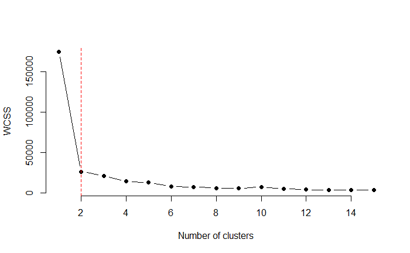

```r
wcss <- c()

for (i in 1:15) {
  kmeans_obj <- kmeans(data[,c("longitude", "latitude")], centers = i)
  wcss[i] <- kmeans_obj$tot.withinss
}

# plot the elbow plot
plot(1:15, wcss, type = "b", pch = 19, frame = FALSE,
     xlab = "Number of clusters", ylab = "WCSS")

# add a vertical line at the "elbow" point
elbow <- which(diff(wcss) <= mean(diff(wcss))) + 1
abline(v = elbow, col = "red", lty = 2)
```

```r
kmeans_cluster <- kmeans(data[,c("longitude", "latitude")], centers = 8)

data$area <-  as.factor(kmeans_obj$cluster)
table(data$area)
```

```
   1    2    3    4    5    6    7    8    9   10   11   12   13   14   15
4615  355 1732 2251  702  716 3193  990  290 1126  446  220 1410 1417  965
```

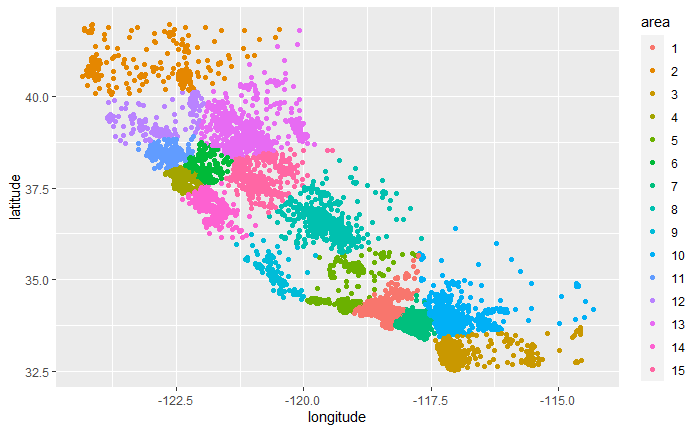

```r
ggplot(data, aes(x=longitude, y=latitude, color = area)) +
  geom_point()
```

A simple scatter plot of the latiude and longitude does a surprisingly good job of showing California. The Major cities of San Francisco, Sacramento, Los Angeles, and San Diego all have distinct colors, with Los Angeles being divided into three colors.

Although this K-means cluster was designed to make the latitude and longitude more meaningful I will still keep these values in the data set. The Random Forest works by selecting the feature that maximizes information gain, if the new clusters do a better job at predicting prices than the latitude and longitude the model will simply select the area when confronted with a choice. In other words Random forest models are robust to meaningless data because it can always ignore a feature in favor of a variable that provides more information gain.

Since I have added new data to the data set I need to resplit my data to make sure the new feature shows up in the training and test set. I simply set the same seed and re-assign

```r
set.seed(38483)

assignment <- sample(c("train", "test"), nrow(data), replace = TRUE, prob = c(.8, .2))

train <- data[assignment == "train",]
test <- data[assignment == "test",]

rm(assignment)

rf_model <- randomForest(median_house_value ~ ., data = train)
print(rf_model)
```

```
Call:
 randomForest(formula = median_house_value ~ ., data = train)
               Type of random forest: regression
                     Number of trees: 500
No. of variables tried at each split: 3

          Mean of squared residuals: 2286460832
                    % Var explained: 82.86
```

```r
rf_test <- predict(rf_model, newdata = test)

rss_rf <- sum((test$median_house_value - rf_test)^2)
tss_rf <- sum((test$median_house_value - mean(test$median_house_value))^2)

r_squared_rf <- 1 -(rss_rf/tss_rf)
r_squared_rf
```

```
[1] 0.8282116
```

Assigning house to areas using their coordinates resulted predicting 82% of the variance, a 4% increase.

Overall I would likely use a Random Forest Model on this data rather than a linear regression. The Random Forest Model has significantly more accuracy at 82%, a considerable feet considering that the square footage of the house, one of the main predictors of price, was not in the data set.